x— title: “Clusturing” output: html_document: default word_document: default date: “2023-11-28” —

```r
# Load packages for data manipulation
library(tidyverse)
library(lubridate)
library(ggplot2)
library(cowplot)
library(dplyr)
library(DT)
library(GGally)
library(cluster)
library(factoextra) # for visualization
library(mice)

# Load data
maindata <- read.csv("maindata.csv")
data_monthly <- read.csv("data_monthly.csv")
```

```r
#data preprocessing
# Create a monthly date sequence from January 1990 to November 2023.
dates <- seq(ymd("1990-01-01"), ymd("2023-11-01"), by = "1 month")

# Assume maindata has been loaded into the environment. Now, add the date column.
maindata <- maindata %>%
  mutate(date = dates)


# Remove variables with excessive missing values (NA)
maindata <- maindata %>% select(-solarradiation, -uvindex)

# Replace NA values with 0
maindata <- maindata %>%
  mutate(
    Clear = replace(Clear, is.na(Clear), 0),
    Overcast = replace(Overcast, is.na(Overcast), 0),
    Partially.cloudy = replace(Partially.cloudy, is.na(Partially.cloudy), 0),
    Rain..Partially.cloudy = replace(Rain..Partially.cloudy, is.na(Rain..Partially.cloudy), 0),
    Rain..Overcast = replace(Rain..Overcast, is.na(Rain..Overcast), 0),
    Rain = replace(Rain, is.na(Rain), 0)
  )
```

# K-means clusturing based on conditions with years on y-axis and cloudcover on x-axis. Each cluster represents one of the conditions.

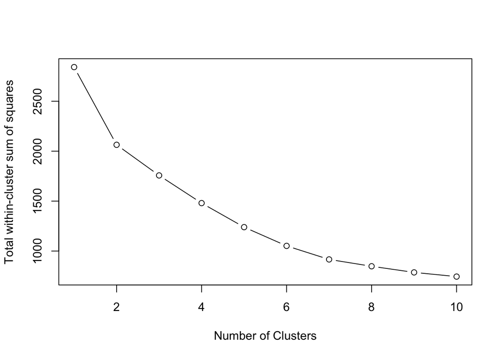

```r
# Selecting the relevant columns for clustering
# Assuming 'maindata' is your dataframe and 'date' column has been formatted as Date type
conditions <- maindata[, c("cloudcover", "Clear", "Overcast", "Partially.cloudy", "Rain..Partially.cloudy", "Rain..Overcast", "Rain")]

# Standardize the conditions data for clustering
conditions_scaled <- scale(conditions)

# Calculate total within-cluster sum of square (wss) for different numbers of clusters
wss <- sapply(1:10, function(k) {
  set.seed(123)
  kmeans(conditions_scaled, centers = k, nstart = 25)$tot.withinss
})

# Plot the Elbow curve
plot(1:10, wss, type = "b", xlab = "Number of Clusters", ylab = "Total within-cluster sum of squares")
```

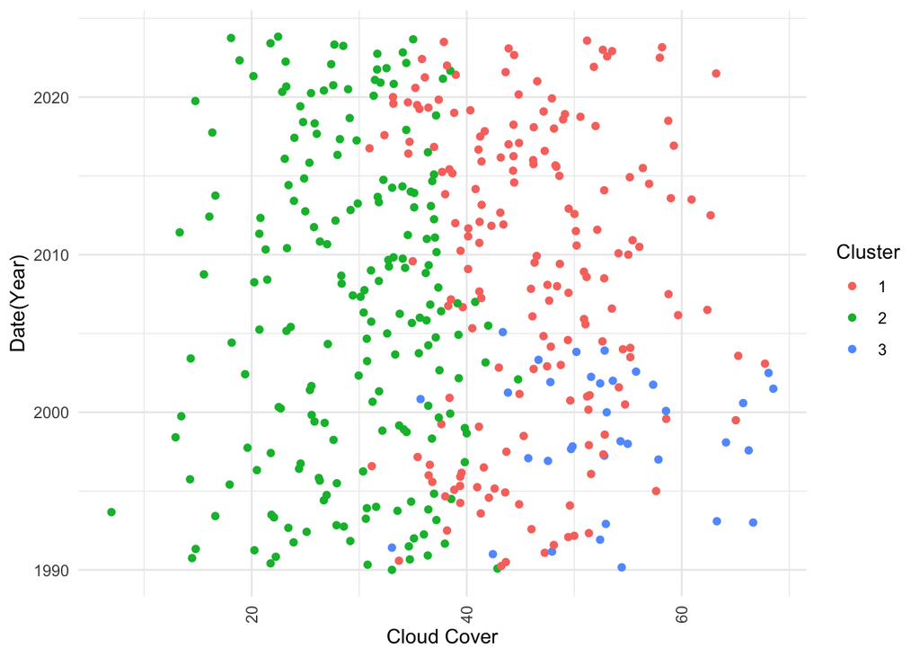

```r
# Determine the optimal number of clusters
# Look for the "elbow" in the plot where the WSS begins to decrease more slowly
# This is often a good choice for the number of clusters

# Assuming the elbow is at k = 3 based on the plot observation
k <- 3

# Now, performing k-means clustering with the optimal number of clusters
set.seed(1234)
km_result <- kmeans(conditions_scaled, centers = k, nstart = 25)

# Add the cluster assignments to the original data
maindata$Cluster <- as.factor(km_result$cluster)

# Visualization
ggplot(maindata, aes(x = cloudcover, y = date, color = Cluster)) +
  geom_point() +
  labs(x = "Cloud Cover", y = "Date(Year)", color = "Cluster") +
  theme_minimal() +
  theme(axis.text.x = element_text(angle = 90, vjust = 0.5, hjust=1))
```

’’’ Basis of Clustering The clustering is conducted on a dataset (maindata) using multiple weather-related variables: cloudcover, Clear, Overcast, Partially.cloudy, Rain..Partially.cloudy, Rain..Overcast, and Rain. These variables encompass different aspects of weather such as cloud cover, clear skies, and various forms of precipitation conditions. The data is first standardized to ensure equal weightage of each variable in the clustering process. K-means clustering is then applied to group the data into clusters based on similarities in these weather conditions.

Summary Each cluster represents a distinct set of weather conditions, differentiated by the specific variables used for clustering. Cluster 1 captures the transitional weather patterns with moderate cloud cover and mixed precipitation. Cluster 2 stands out for its clear, sunny, and dry conditions. In contrast, Cluster 3 represents the overcast and rainy days with higher humidity and cooler temperatures. This clustering approach, therefore, effectively segments the data into meaningful categories based on comprehensive weather parameters, providing a nuanced understanding of different weather patterns. Such insights are valuable for applications in meteorology, climate studies, and environmental planning.

Cluster 1 -Weather Pattern Cloud Cover: Moderate (average of 46.09%). Temperature: Warmer (average 24.28°C). Humidity: Moderate (36.60%). Other Conditions: Tendency towards partially cloudy and partially rainy conditions.

-Interpretation Represents days with a mix of cloudiness and occasional rain, typical of transitional weather patterns. This cluster captures the variability of weather with moderate cloud cover and varied precipitation.

Cluster 2 -Weather Pattern Cloud Cover: Low (average of 29.18%). Temperature: Slightly warmer (average 24.79°C). Humidity: Lower (27.32%). Other Conditions: Dominantly clear days.

-Interpretation Characterized by clear, dry, and sunny conditions. This cluster distinctly represents the stable and dry weather patterns, making it significantly different from the others in terms of clear sky conditions.

Cluster 3 -Weather Pattern Cloud Cover: High (average 53.17%). Temperature: Cooler (average 20.02°C). Humidity: Higher (40.68%). Other Conditions: Frequent overcast and rainy conditions.

-Interpretation Signifies days with consistent overcast and rainy weather. This cluster is indicative of the more humid and wet conditions, differing from the others by its persistent cloud cover and higher precipitation. ’’’

```r
# Viewing the centroids of the clusters
km_result$centers
```

```
##   cloudcover      Clear   Overcast Partially.cloudy Rain..Partially.cloudy
## 1  0.6258030 -0.7671763 -0.2860979        0.5563556              0.6003162
## 2 -0.7942975  0.8307888 -0.2383997       -0.5772177             -0.5070502
## 3  1.2200224 -0.7033041  2.7764278        0.3699692             -0.2425297
##   Rain..Overcast         Rain
## 1      0.1517950  0.035341421
## 2     -0.2949456  0.002838469
## 3      0.8628551 -0.195469596
```

```r
# Calculate summary statistics for each cluster
cluster_summary <- maindata %>%
  group_by(Cluster) %>%
  summarise(
    Mean_CloudCover = mean(cloudcover),
    Median_CloudCover = median(cloudcover),
    Min_CloudCover = min(cloudcover),
    Max_CloudCover = max(cloudcover)
  )

# Print cluster-wise summary statistics
print(cluster_summary)
```

```
## # A tibble: 3 × 5
##   Cluster Mean_CloudCover Median_CloudCover Min_CloudCover Max_CloudCover
##   <fct>             <dbl>             <dbl>          <dbl>          <dbl>
## 1 1                  46.1              46.1          31.0            67.7
## 2 2                  29.2              30.2           6.96           44.8
## 3 3                  53.2              52.8          33.0            68.5
```

```r
# Check the average of other climate variables by cluster.
aggregate(cbind(temp, humidity, windspeed, sealevelpressure, precip) ~ Cluster, data = maindata, FUN = mean)
```

```
##   Cluster     temp humidity windspeed sealevelpressure    precip
## 1       1 24.27700 36.59550  20.91499         1012.287 0.7296938
## 2       2 24.78826 27.32393  20.26958         1011.559 0.2534734
## 3       3 20.01704 40.67974  19.50182         1014.250 0.7583318
```

```r
# Check the cluster frequencies by date
table(maindata$date, maindata$Cluster)
```

[output not shown]

[output cut: 354 more lines]

```
##   2022-09-01 1 0 0
##   2022-10-01 0 1 0
##   2022-11-01 0 1 0
##   2022-12-01 1 0 0
##   2023-01-01 1 0 0
##   2023-02-01 1 0 0
##   2023-03-01 1 0 0
##   2023-04-01 0 1 0
##   2023-05-01 0 1 0
##   2023-06-01 0 1 0
##   2023-07-01 1 0 0
##   2023-08-01 1 0 0
##   2023-09-01 0 1 0
##   2023-10-01 0 1 0
##   2023-11-01 0 1 0
```